# Resampling with mosaic

Randall Pruim  
eCOTS 2014

## You can do() it.

### Lady Tasting Tea

- Often used on first day of class
- Story
  - woman claims she can tell whether milk has been poured into tea or vice versa.
  - Question: How do we test this claim?

### Lady Tasting Tea

- Often used on first day of class
- Story
  - woman claims she can tell whether milk has been poured into tea or vice versa.
  - Question: How do we test this claim?
    - Have her taste some tea prepared each way  
      (Flip a coin to decide which way.)
    - How many cups? (Let's try 10.)
    - How do we evaluate her score?

### Physical Simulation

- Have students guess a sequence of 10 heads and tails.
- Flip a coin 10 times and compare.
- Before the reveal, ask students
  - What do you expect your score to be?
  - What do you think the best score in the class will be?
  - Is a perfect score possible just by guessing? Likely?
  - What about 9 out of 10?

### Computer Simulation

Use `rflip()` to simulate flipping coins

```r
rflip()
```

```
Flipping 1 coin [ Prob(Heads) = 0.5 ] ...

H

Number of Heads: 1 [Proportion Heads: 1]
```

### Computer Simulation

Faster if we flip multiple coins at once:

```r
rflip(10)
```

```
Flipping 10 coins [ Prob(Heads) = 0.5 ] ...

H H H T T T H H H T

Number of Heads: 6 [Proportion Heads: 0.6]
```

- easier to consider `heads` = correct; `tails` = incorrect than to compare with a given pattern
  - this switch bothers me more than it bothers my students

### Let's do that a lot of times

`rflip(10)` simulates 1 lady tasting 10 cups 1 time.

We can do that many times to see how guessing ladies do:

```r
do(2) * rflip(10)
```

```
   n heads tails prop
1 10     3     7  0.3
2 10     5     5  0.5
```

- `do()` is clever about what it remembers
- 2 isn't many – we'll do many next.

### The distribution of guessing ladies

```r
Ladies <- do(5000) * rflip(10)
head(Ladies, 1)
```

```
   n heads tails prop
1 10     4     6  0.4
```

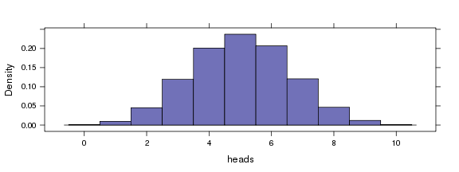

```r
histogram( ~ heads, data=Ladies, width=1 )
```

### How often does guessing score 9 or 10?

```r
tally( ~(heads >= 9) , data=Ladies)
```

```
 TRUE FALSE
   63  4937
```

### How often does guessing score 9 or 10?

```r
tally( ~(heads >= 9) , data=Ladies,
                       format="prop")
```

```
  TRUE  FALSE
0.0126 0.9874
```

### How often does guessing score 9 or 10?

```r
tally( ~(heads >= 9) , data=Ladies,
                       format="prop")
```

```
  TRUE  FALSE
0.0126 0.9874
```

```r
 prop( ~(heads >= 9), data=Ladies)
```

```
  TRUE
0.0126
```

### A general approach to randomization

1. Do it for your data
2. Do it for “random” data
3. Do it lots of times for “random” data
- definition of “random” is important, but can often be handled by `shuffle()` or `resample()`

### Example: Do mean ages differ by sex?

```r
diffmean(age ~ sex, data=HELPrct)
```

```
diffmean
 -0.7841
```

```r
do(1) *
  diffmean(age ~ shuffle(sex), data=HELPrct)
```

```
  diffmean
1    1.798
```

```r
Null <- do(5000) *
  diffmean(age ~ shuffle(sex), data=HELPrct)
```

### Example: Do mean ages differ by sex?

```r
prop( ~(abs(diffmean) > 0.7841), data=Null )
```

```
  TRUE
0.3586
```

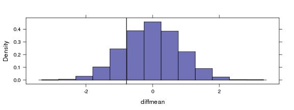

```r
histogram(~ diffmean, data=Null, v=-.7841)
```

### Example: Bootstrap for difference in means

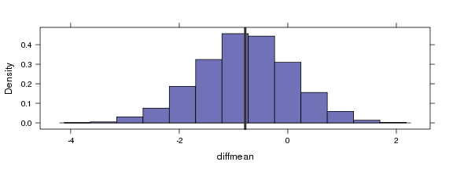

```r
Bootstrap <- do(5000) *
  diffmean(age~sex, data= resample(HELPrct))

histogram( ~diffmean, data=Bootstrap,
                      v=-.7841, glwd=4 )
```

### Example: CI for difference in mean ages

```r
cdata(~diffmean, data=Bootstrap, p=.95)
```

```
      low        hi central.p
  -2.4617    0.8276    0.9500
```

```r
confint(Bootstrap, method="quantile")
```

```
      name  lower  upper level   method
1 diffmean -2.462 0.8276  0.95 quantile
```

### Example: CI for difference in mean ages

```r
confint(Bootstrap)  # default uses st. err
```

```
      name  lower  upper level method estimate margin.of.error
1 diffmean -2.432 0.8761  0.95 stderr   -0.778           1.654
```

### Randomization and linear models

```r
do(1) * lm(width ~ length, data=KidsFeet)
```

```
  Intercept length  sigma r.squared
1     2.862 0.2479 0.3963     0.411
```

```r
do(3) * lm( width ~ shuffle(length), data=KidsFeet)
```

```
  Intercept    length  sigma r.squared
1     8.975 0.0007113 0.5164 3.382e-06
2     8.416 0.0232976 0.5155 3.629e-03
3     8.345 0.0261777 0.5152 4.581e-03
```

### Randomization and linear models

```r
do(1) *
  lm(width ~ length + sex, data=KidsFeet)
```

```
  Intercept length    sexG  sigma r.squared
1     3.641  0.221 -0.2325 0.3849    0.4595
```

```r
do(3) *
  lm( width ~ length + shuffle(sex),
                       data=KidsFeet)
```

```
  Intercept length      sexG  sigma r.squared
1     2.907 0.2486 -0.127647 0.3963    0.4271
2     2.883 0.2464  0.034996 0.4014    0.4122
3     2.849 0.2487 -0.008942 0.4018    0.4111
```

### Randomization and linear models

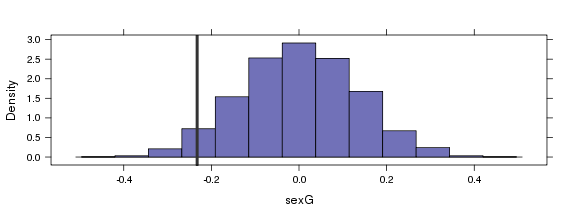

```r
Null <- do(5000) *
  lm( width ~ length + shuffle(sex),
                       data=KidsFeet)
histogram( ~ sexG, data=Null,
           v=-0.2325, glwd=4)
```

### Randomization and linear models

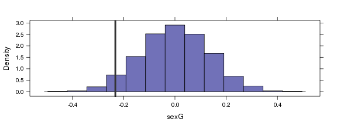

```r
histogram( ~ sexG, data=Null,
           v=-0.2325, glwd=4)
```

```r
prop( ~ (sexG <= -0.2325), data=Null )
```

```
  TRUE
0.0382
```